# code

#### Harika Ravi

##### Student Number: 9032698

##### Section 1: Practical Lab 1 - Univariate Linear Regression on the California Housing Prices Dataset

##### Description for the following USE-CASE:

In this lab, we are about ot tackel the challenge of predicting Housing Prices in California using the Linear Regression models. We aim to understand how the population, number of houses, dependent variables act as the factors influencing the housing prices. This approach helps in identifying the key-factor of housing costs and can be useful for making informed decisions in the real estate and urban planing.

##### STEP-1: Loading the data

Source: Downloaded from Kaggle California Housing Prices

url = "https://www.kaggle.com/camnugent/california-housing-prices"

```python
# Impoting the library pandas
import pandas as pd
# Load the dataset that is downloaded from kaggle and read the CSV file into dataframes.
data = pd.read_csv(r'C:\Users\harik\OneDrive\Documents\GitHub\Housing-lab\housing.csv')
# Here we give the path where the CSV file is peresent in local
```

##### Data Exploration (EDA)

```python
data.describe()
```

|  | longitude | latitude | housing_median_age | total_rooms | total_bedrooms | population | households | median_income | median_house_value |
| --- | --- | --- | --- | --- | --- | --- | --- | --- | --- |
| count | 20640.000000 | 20640.000000 | 20640.000000 | 20640.000000 | 20433.000000 | 20640.000000 | 20640.000000 | 20640.000000 | 20640.000000 |
| mean | -119.569704 | 35.631861 | 28.639486 | 2635.763081 | 537.870553 | 1425.476744 | 499.539680 | 3.870671 | 206855.816909 |
| std | 2.003532 | 2.135952 | 12.585558 | 2181.615252 | 421.385070 | 1132.462122 | 382.329753 | 1.899822 | 115395.615874 |
| min | -124.350000 | 32.540000 | 1.000000 | 2.000000 | 1.000000 | 3.000000 | 1.000000 | 0.499900 | 14999.000000 |
| 25% | -121.800000 | 33.930000 | 18.000000 | 1447.750000 | 296.000000 | 787.000000 | 280.000000 | 2.563400 | 119600.000000 |
| 50% | -118.490000 | 34.260000 | 29.000000 | 2127.000000 | 435.000000 | 1166.000000 | 409.000000 | 3.534800 | 179700.000000 |
| 75% | -118.010000 | 37.710000 | 37.000000 | 3148.000000 | 647.000000 | 1725.000000 | 605.000000 | 4.743250 | 264725.000000 |
| max | -114.310000 | 41.950000 | 52.000000 | 39320.000000 | 6445.000000 | 35682.000000 | 6082.000000 | 15.000100 | 500001.000000 |

##### STEP-2: Importing the necessary Library functions

```python
# We need to access libraries like numpy,matplotlib,scikit-learn to perform the necesaary operation.
import numpy as np
# numpy is for numerical operatoins and for arrays as well.
import matplotlib.pyplot as plt
# matplotlib is for visualizations and ploting the graphs.
import seaborn as sns
# seaborn is a interface for attractive and statistical graphics
from sklearn.linear_model import LinearRegression
# liner_model that is in sklearn that contains lineraRegression for creating the models.
from sklearn.model_selection import train_test_split
# model_selection in sklearn contains train_test_split for splitting dataset into training and testing sets.
```

##### STEP-3: For scatter plots of each individual against median house value

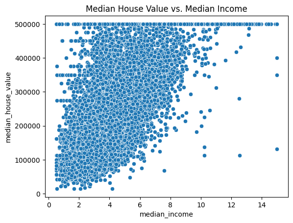

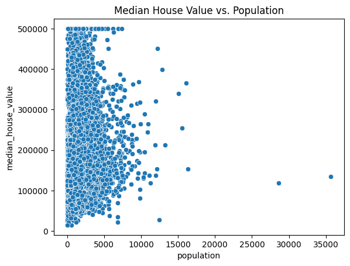

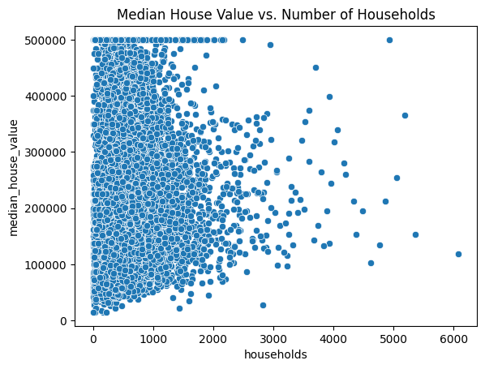

```python
# Scatter plot for median income vs. median house value
sns.scatterplot(x='median_income', y='median_house_value', data=data)
plt.title('Median House Value vs. Median Income')
plt.show()

# Scatter plot for population vs. median house value
sns.scatterplot(x='population', y='median_house_value', data=data)
plt.title('Median House Value vs. Population')
plt.show()

# Scatter plot for number of households vs. median house value
sns.scatterplot(x='households', y='median_house_value', data=data)
plt.title('Median House Value vs. Number of Households')
plt.show()
```

##### STEP-4: Defining the independent and dependent variables

```python
# Define the independent variables
# The independent variables are the features used to predict the dependent variables
X_median_income = data[['median_income']]
X_population = data[['population']]
X_households = data[['households']]

# Define the dependent variable
# The dependent variables target the variables that we want to predict,which will be the median house value
y = data['median_house_value']
```

##### STEP-5: Splitting the data into training and testing sets

```python
# Here we need to split data into testing part and training part
# while the testing part is used to evaluate the performance of the model
# We use the training part to train the model to identify

# Split the data for median income
X_train_income, X_test_income, y_train, y_test = train_test_split(X_median_income, y, test_size=0.2, random_state=42)

# Split the data for population
X_train_population, X_test_population, y_train, y_test = train_test_split(X_population, y, test_size=0.2, random_state=42)

# Split the data for households
X_train_households, X_test_households, y_train, y_test = train_test_split(X_households, y, test_size=0.2, random_state=42)
```

##### STEP-6: Train the Linear Regression Model

```python
# We create & train a separate LinearRegression model for each independent variable
# The fit method is used to train the model on the training data

# Train the model for median income
model_income = LinearRegression()
model_income.fit(X_train_income, y_train)

# Train the model for population
model_population = LinearRegression()
model_population.fit(X_train_population, y_train)

# Train the model for households
model_households = LinearRegression()
model_households.fit(X_train_households, y_train)
```

```
LinearRegression()
```

##### STEP-7: Running Linear Regression Model

```python
from sklearn.linear_model import LinearRegression
from sklearn.metrics import mean_squared_error, mean_absolute_error

# Function to run linear regression and return parameters and errors
def run_linear_regression(X, y):
    model = LinearRegression()
    model.fit(X, y)
    intercept = model.intercept_
    slope = model.coef_[0]
    predictions = model.predict(X)
    mse = mean_squared_error(y, predictions)
    mae = mean_absolute_error(y, predictions)
    return intercept, slope, mse, mae

# Median house value vs. median income
X_income = data[['median_income']]
y = data['median_house_value']
intercept_income, slope_income, mse_income, mae_income = run_linear_regression(X_income, y)

# Median house value vs. population
X_population = data[['population']]
intercept_population, slope_population, mse_population, mae_population = run_linear_regression(X_population, y)

# Median house value vs. number of households
X_households = data[['households']]
intercept_households, slope_households, mse_households, mae_households = run_linear_regression(X_households, y)
```

##### STEP-8: Plotting Regression lines on the top of scatter plot

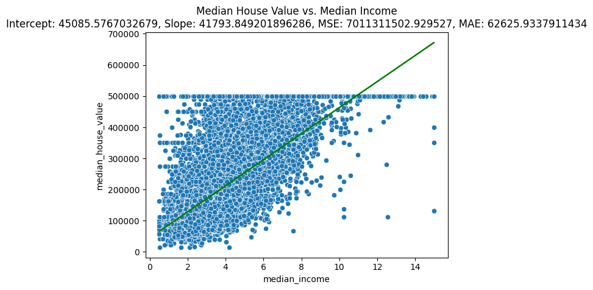

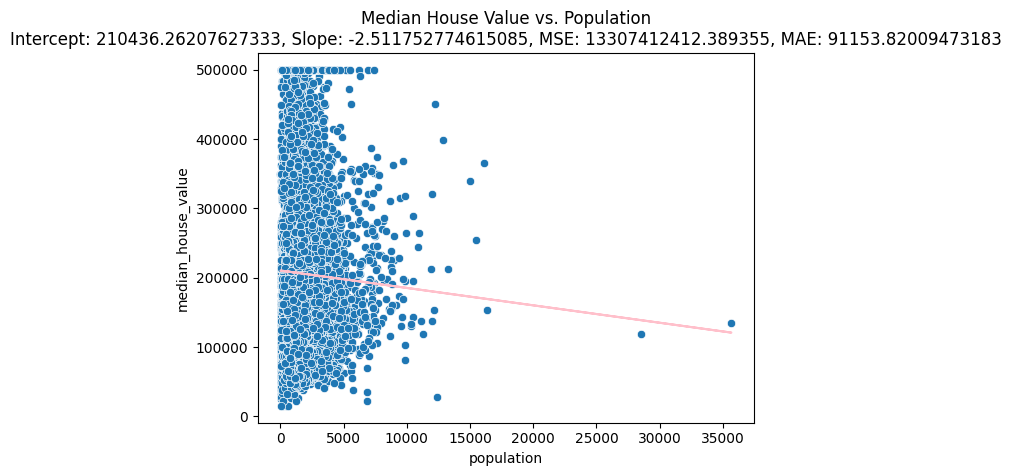

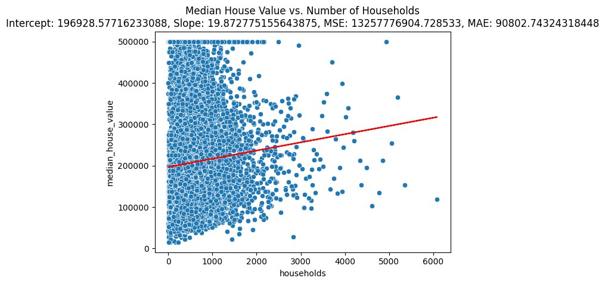

```python
# Plot for median income vs. median house value
sns.scatterplot(x='median_income', y='median_house_value', data=data)
plt.plot(data['median_income'], intercept_income + slope_income * data['median_income'], color='green')
plt.title(f'Median House Value vs. Median Income\nIntercept: {intercept_income}, Slope: {slope_income}, MSE: {mse_income}, MAE: {mae_income}')
plt.show()

# Plot for population vs. median house value
sns.scatterplot(x='population', y='median_house_value', data=data)
plt.plot(data['population'], intercept_population + slope_population * data['population'], color='pink')
plt.title(f'Median House Value vs. Population\nIntercept: {intercept_population}, Slope: {slope_population}, MSE: {mse_population}, MAE: {mae_population}')
plt.show()

# Plot for number of households vs. median house value
sns.scatterplot(x='households', y='median_house_value', data=data)
plt.plot(data['households'], intercept_households + slope_households * data['households'], color='red')
plt.title(f'Median House Value vs. Number of Households\nIntercept: {intercept_households}, Slope: {slope_households}, MSE: {mse_households}, MAE: {mae_households}')
plt.show()
```

##### STEP-9: Evaluate the models

```python
from sklearn.metrics import mean_squared_error, r2_score
# Evaluating the performance of the linear regression using the two metrics:
# 1.mean_squared_error (MSE): measures the average squared difference between the actual and predicted values
# 2.r2-score: measures how well the independent variable explains the variability of the dependent variable

# Evaluate the model for median income
y_pred_income = model_income.predict(X_test_income)
print('Median Income Model:')
print('R-squared:', r2_score(y_test, y_pred_income))
print('Mean Squared Error:', mean_squared_error(y_test, y_pred_income))
print()

# Evaluate the model for population
y_pred_population = model_population.predict(X_test_population)
print('Population Model:')
print('R-squared:', r2_score(y_test, y_pred_population))
print('Mean Squared Error:', mean_squared_error(y_test, y_pred_population))
print()

# Evaluate the model for households
y_pred_households = model_households.predict(X_test_households)
print('Households Model:')
print('R-squared:', r2_score(y_test, y_pred_households))
print('Mean Squared Error:', mean_squared_error(y_test, y_pred_households))
```

```
Median Income Model:
R-squared: 0.45885918903846656
Mean Squared Error: 7091157771.76555

Population Model:
R-squared: 9.303316180364618e-05
Mean Squared Error: 13102870667.503983

Households Model:
R-squared: 0.005228201940277177
Mean Squared Error: 13035578954.783041
```

##### Conclusion:

In this lab, we performed univariate linear regression on the California Housing Prices Dataset to predict housing prices based on three independent variables: median income, population, and number of households. We loaded the dataset, split it into training and testing sets, trained linear regression models, evaluated their performance using R-squared and Mean Squared Error, and visualized the results with scatter plots and regression lines.

#### Harika Ravi

##### Student Number: 9032698

##### Section 1: Practical Lab 1 - Univariate Linear Regression on the California Housing Prices Dataset

##### Description for the following USE-CASE:

In this lab, we are about ot tackel the challenge of predicting Housing Prices in California using the Linear Regression models. We aim to understand how the population, number of houses, dependent variables act as the factors influencing the housing prices. This approach helps in identifying the key-factor of housing costs and can be useful for making informed decisions in the real estate and urban planing.

##### STEP-1: Loading the data

Source: Downloaded from Kaggle California Housing Prices

url = "https://www.kaggle.com/camnugent/california-housing-prices"

```python
# Impoting the library pandas
import pandas as pd
# Load the dataset that is downloaded from kaggle and read the CSV file into dataframes.
data = pd.read_csv(r'C:\Users\harik\OneDrive\Documents\GitHub\Housing-lab\housing.csv')
# Here we give the path where the CSV file is peresent in local
```

##### Data Exploration (EDA)

```python
data.describe()
```

|  | longitude | latitude | housing_median_age | total_rooms | total_bedrooms | population | households | median_income | median_house_value |
| --- | --- | --- | --- | --- | --- | --- | --- | --- | --- |
| count | 20640.000000 | 20640.000000 | 20640.000000 | 20640.000000 | 20433.000000 | 20640.000000 | 20640.000000 | 20640.000000 | 20640.000000 |
| mean | -119.569704 | 35.631861 | 28.639486 | 2635.763081 | 537.870553 | 1425.476744 | 499.539680 | 3.870671 | 206855.816909 |
| std | 2.003532 | 2.135952 | 12.585558 | 2181.615252 | 421.385070 | 1132.462122 | 382.329753 | 1.899822 | 115395.615874 |
| min | -124.350000 | 32.540000 | 1.000000 | 2.000000 | 1.000000 | 3.000000 | 1.000000 | 0.499900 | 14999.000000 |
| 25% | -121.800000 | 33.930000 | 18.000000 | 1447.750000 | 296.000000 | 787.000000 | 280.000000 | 2.563400 | 119600.000000 |
| 50% | -118.490000 | 34.260000 | 29.000000 | 2127.000000 | 435.000000 | 1166.000000 | 409.000000 | 3.534800 | 179700.000000 |
| 75% | -118.010000 | 37.710000 | 37.000000 | 3148.000000 | 647.000000 | 1725.000000 | 605.000000 | 4.743250 | 264725.000000 |
| max | -114.310000 | 41.950000 | 52.000000 | 39320.000000 | 6445.000000 | 35682.000000 | 6082.000000 | 15.000100 | 500001.000000 |

##### STEP-2: Importing the necessary Library functions

```python
# We need to access libraries like numpy,matplotlib,scikit-learn to perform the necesaary operation.
import numpy as np
# numpy is for numerical operatoins and for arrays as well.
import matplotlib.pyplot as plt
# matplotlib is for visualizations and ploting the graphs.
import seaborn as sns
# seaborn is a interface for attractive and statistical graphics
from sklearn.linear_model import LinearRegression
# liner_model that is in sklearn that contains lineraRegression for creating the models.
from sklearn.model_selection import train_test_split
# model_selection in sklearn contains train_test_split for splitting dataset into training and testing sets.
```

##### STEP-3: For scatter plots of each individual against median house value

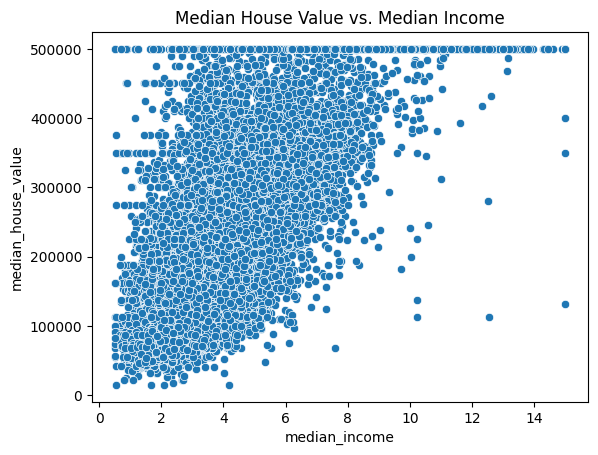

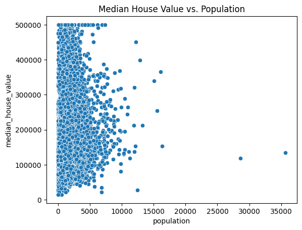

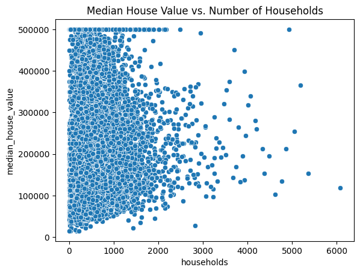

```python
# Scatter plot for median income vs. median house value
sns.scatterplot(x='median_income', y='median_house_value', data=data)
plt.title('Median House Value vs. Median Income')
plt.show()

# Scatter plot for population vs. median house value
sns.scatterplot(x='population', y='median_house_value', data=data)
plt.title('Median House Value vs. Population')
plt.show()

# Scatter plot for number of households vs. median house value
sns.scatterplot(x='households', y='median_house_value', data=data)
plt.title('Median House Value vs. Number of Households')
plt.show()
```

##### STEP-4: Defining the independent and dependent variables

```python
# Define the independent variables
# The independent variables are the features used to predict the dependent variables
X_median_income = data[['median_income']]
X_population = data[['population']]
X_households = data[['households']]

# Define the dependent variable
# The dependent variables target the variables that we want to predict,which will be the median house value
y = data['median_house_value']
```

##### STEP-5: Splitting the data into training and testing sets

```python
# Here we need to split data into testing part and training part
# while the testing part is used to evaluate the performance of the model
# We use the training part to train the model to identify

# Split the data for median income
X_train_income, X_test_income, y_train, y_test = train_test_split(X_median_income, y, test_size=0.2, random_state=42)

# Split the data for population
X_train_population, X_test_population, y_train, y_test = train_test_split(X_population, y, test_size=0.2, random_state=42)

# Split the data for households
X_train_households, X_test_households, y_train, y_test = train_test_split(X_households, y, test_size=0.2, random_state=42)
```

##### STEP-6: Train the Linear Regression Model

```python
# We create & train a separate LinearRegression model for each independent variable
# The fit method is used to train the model on the training data

# Train the model for median income
model_income = LinearRegression()
model_income.fit(X_train_income, y_train)

# Train the model for population
model_population = LinearRegression()
model_population.fit(X_train_population, y_train)

# Train the model for households
model_households = LinearRegression()
model_households.fit(X_train_households, y_train)
```

```
LinearRegression()
```

##### STEP-7: Running Linear Regression Model

```python
from sklearn.linear_model import LinearRegression
from sklearn.metrics import mean_squared_error, mean_absolute_error

# Function to run linear regression and return parameters and errors
def run_linear_regression(X, y):
    model = LinearRegression()
    model.fit(X, y)
    intercept = model.intercept_
    slope = model.coef_[0]
    predictions = model.predict(X)
    mse = mean_squared_error(y, predictions)
    mae = mean_absolute_error(y, predictions)
    return intercept, slope, mse, mae

# Median house value vs. median income
X_income = data[['median_income']]
y = data['median_house_value']
intercept_income, slope_income, mse_income, mae_income = run_linear_regression(X_income, y)

# Median house value vs. population
X_population = data[['population']]
intercept_population, slope_population, mse_population, mae_population = run_linear_regression(X_population, y)

# Median house value vs. number of households
X_households = data[['households']]
intercept_households, slope_households, mse_households, mae_households = run_linear_regression(X_households, y)
```

##### STEP-8: Plotting Regression lines on the top of scatter plot

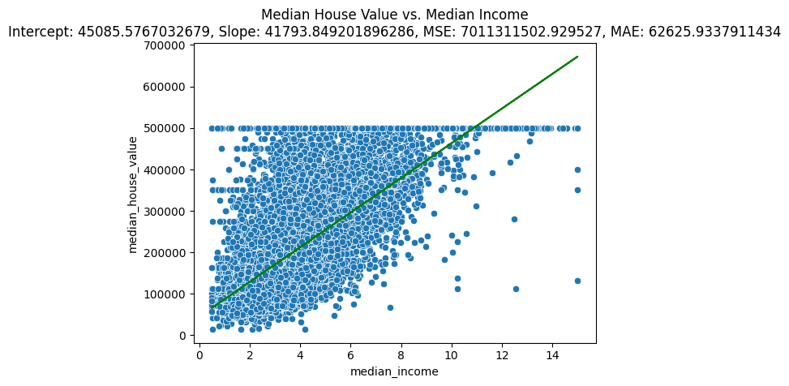

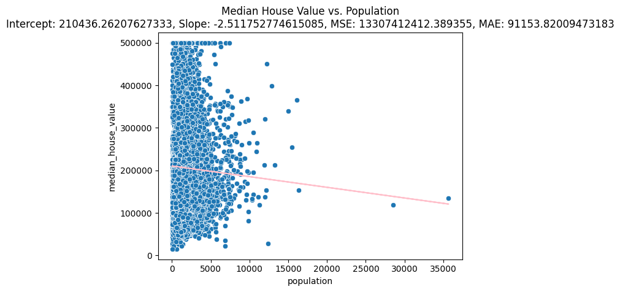

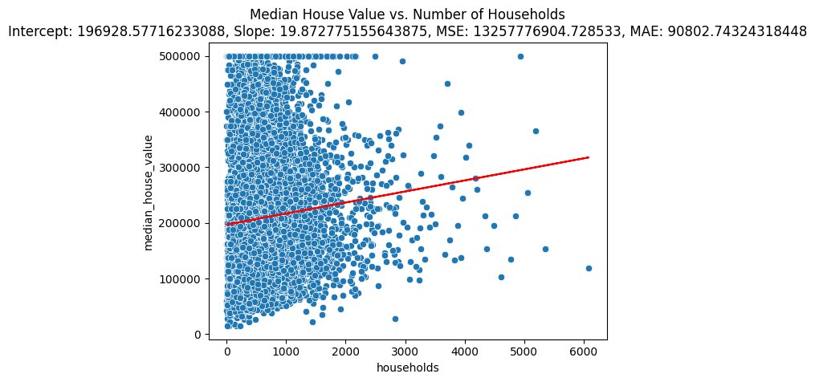

```python
# Plot for median income vs. median house value
sns.scatterplot(x='median_income', y='median_house_value', data=data)
plt.plot(data['median_income'], intercept_income + slope_income * data['median_income'], color='green')
plt.title(f'Median House Value vs. Median Income\nIntercept: {intercept_income}, Slope: {slope_income}, MSE: {mse_income}, MAE: {mae_income}')
plt.show()

# Plot for population vs. median house value
sns.scatterplot(x='population', y='median_house_value', data=data)
plt.plot(data['population'], intercept_population + slope_population * data['population'], color='pink')
plt.title(f'Median House Value vs. Population\nIntercept: {intercept_population}, Slope: {slope_population}, MSE: {mse_population}, MAE: {mae_population}')
plt.show()

# Plot for number of households vs. median house value
sns.scatterplot(x='households', y='median_house_value', data=data)
plt.plot(data['households'], intercept_households + slope_households * data['households'], color='red')
plt.title(f'Median House Value vs. Number of Households\nIntercept: {intercept_households}, Slope: {slope_households}, MSE: {mse_households}, MAE: {mae_households}')
plt.show()
```

##### STEP-9: Evaluate the models

```python
from sklearn.metrics import mean_squared_error, r2_score
# Evaluating the performance of the linear regression using the two metrics:
# 1.mean_squared_error (MSE): measures the average squared difference between the actual and predicted values
# 2.r2-score: measures how well the independent variable explains the variability of the dependent variable

# Evaluate the model for median income
y_pred_income = model_income.predict(X_test_income)
print('Median Income Model:')
print('R-squared:', r2_score(y_test, y_pred_income))
print('Mean Squared Error:', mean_squared_error(y_test, y_pred_income))
print()

# Evaluate the model for population
y_pred_population = model_population.predict(X_test_population)
print('Population Model:')
print('R-squared:', r2_score(y_test, y_pred_population))
print('Mean Squared Error:', mean_squared_error(y_test, y_pred_population))
print()

# Evaluate the model for households
y_pred_households = model_households.predict(X_test_households)
print('Households Model:')
print('R-squared:', r2_score(y_test, y_pred_households))
print('Mean Squared Error:', mean_squared_error(y_test, y_pred_households))
```

```
Median Income Model:
R-squared: 0.45885918903846656
Mean Squared Error: 7091157771.76555

Population Model:
R-squared: 9.303316180364618e-05
Mean Squared Error: 13102870667.503983

Households Model:
R-squared: 0.005228201940277177
Mean Squared Error: 13035578954.783041
```

##### Conclusion:

In this lab, we performed univariate linear regression on the California Housing Prices Dataset to predict housing prices based on three independent variables: median income, population, and number of households. We loaded the dataset, split it into training and testing sets, trained linear regression models, evaluated their performance using R-squared and Mean Squared Error, and visualized the results with scatter plots and regression lines.